# Projet: Investiguer la Base de Données des Films "The Movies Database"

## Table des Matières

- Introduction
- Traitement des Données
- Analyse Exploratoire des Données
- Conclusions

## Introduction

L'ensemble de données sur les films contient des informations sur 10 000 films recueillies auprès de The Movie Database (TMDb). Cet ensemble de données comprend les avis des utilisateurs, les revenus, les acteurs, le genre, le directeur et la boîte de production comme principales variables à étudier.

Compte tenu de tout cela, la principale question à se poser est la suivante : **Quels sont les critères de succès d'un film?**

Comme il n'existe pas de définition précise d'un film à succès, nous pouvons citer deux variables cruciales à cet égard :

1. Le film est un succès commercial en termes de profits.
2. le film est hautement noté par le public - Populairité.

Pour cela, nous allons étudier les différents critères qui font le succès d'un film du point de vue commercial et du point de vue du public.

Nous pouvons décomposer cette question générale en questions spécifiques afin d'orienter notre analyse et d'obtenir la réponse précise:

1. Success Commerciale: Quels critères sont associés aux films qui ont des revenus élevés?
2. Popularité: Quels critères sont associés aux films qui ont des votes élevés?
3. Un film populaire signifie-t-il directement un film commercialement réussi?

Enfin, il est particulièrement intéressant d'étudier l'évolution des bénéfices au fil des ans.

La conclusion de toutes les analyses sera détaillée à la fin de ce rapport et répond à la question principale.

## Importation des Paquets et La Base de Données

Dans cette premiere section du rapport, nous allons charger les pqauets necessaires aisni que la base de données des films.

```python
# Importing necessary packages
import pandas as pd

import numpy as np

import matplotlib.pyplot as plt

import seaborn as sns


#Importing the database we will work on
df = pd.read_csv('tmdb-movies.csv')
```

## Traitement des Données

Dans cette section du rapport, nous allons charger les données, vérifier leur propreté, puis découper et nettoyer notre ensemble de données pour l'analyse.

### Propriétés Générales

```python
# Load the database
df.head()
```

|  | id | imdb_id | popularity | budget | revenue | original_title | cast | homepage | director | tagline | ... | overview | runtime | genres | production_companies | release_date | vote_count | vote_average | release_year | budget_adj | revenue_adj |
| --- | --- | --- | --- | --- | --- | --- | --- | --- | --- | --- | --- | --- | --- | --- | --- | --- | --- | --- | --- | --- | --- |
| 0 | 135397 | tt0369610 | 32.985763 | 150000000 | 1513528810 | Jurassic World | Chris Pratt\|Bryce Dallas Howard\|Irrfan Khan\|Vi... | http://www.jurassicworld.com/ | Colin Trevorrow | The park is open. | ... | Twenty-two years after the events of Jurassic ... | 124 | Action\|Adventure\|Science Fiction\|Thriller | Universal Studios\|Amblin Entertainment\|Legenda... | 6/9/15 | 5562 | 6.5 | 2015 | 1.379999e+08 | 1.392446e+09 |
| 1 | 76341 | tt1392190 | 28.419936 | 150000000 | 378436354 | Mad Max: Fury Road | Tom Hardy\|Charlize Theron\|Hugh Keays-Byrne\|Nic... | http://www.madmaxmovie.com/ | George Miller | What a Lovely Day. | ... | An apocalyptic story set in the furthest reach... | 120 | Action\|Adventure\|Science Fiction\|Thriller | Village Roadshow Pictures\|Kennedy Miller Produ... | 5/13/15 | 6185 | 7.1 | 2015 | 1.379999e+08 | 3.481613e+08 |
| 2 | 262500 | tt2908446 | 13.112507 | 110000000 | 295238201 | Insurgent | Shailene Woodley\|Theo James\|Kate Winslet\|Ansel... | http://www.thedivergentseries.movie/#insurgent | Robert Schwentke | One Choice Can Destroy You | ... | Beatrice Prior must confront her inner demons ... | 119 | Adventure\|Science Fiction\|Thriller | Summit Entertainment\|Mandeville Films\|Red Wago... | 3/18/15 | 2480 | 6.3 | 2015 | 1.012000e+08 | 2.716190e+08 |
| 3 | 140607 | tt2488496 | 11.173104 | 200000000 | 2068178225 | Star Wars: The Force Awakens | Harrison Ford\|Mark Hamill\|Carrie Fisher\|Adam D... | http://www.starwars.com/films/star-wars-episod... | J.J. Abrams | Every generation has a story. | ... | Thirty years after defeating the Galactic Empi... | 136 | Action\|Adventure\|Science Fiction\|Fantasy | Lucasfilm\|Truenorth Productions\|Bad Robot | 12/15/15 | 5292 | 7.5 | 2015 | 1.839999e+08 | 1.902723e+09 |
| 4 | 168259 | tt2820852 | 9.335014 | 190000000 | 1506249360 | Furious 7 | Vin Diesel\|Paul Walker\|Jason Statham\|Michelle ... | http://www.furious7.com/ | James Wan | Vengeance Hits Home | ... | Deckard Shaw seeks revenge against Dominic Tor... | 137 | Action\|Crime\|Thriller | Universal Pictures\|Original Film\|Media Rights ... | 4/1/15 | 2947 | 7.3 | 2015 | 1.747999e+08 | 1.385749e+09 |

5 rows × 21 columns

```python
print(df.shape)
df.info()
```

```
(10866, 21)
<class 'pandas.core.frame.DataFrame'>
RangeIndex: 10866 entries, 0 to 10865
Data columns (total 21 columns):
 #   Column                Non-Null Count  Dtype
---  ------                --------------  -----
 0   id                    10866 non-null  int64
 1   imdb_id               10856 non-null  object
 2   popularity            10866 non-null  float64
 3   budget                10866 non-null  int64
 4   revenue               10866 non-null  int64
 5   original_title        10866 non-null  object
 6   cast                  10790 non-null  object
 7   homepage              2936 non-null   object
 8   director              10822 non-null  object
 9   tagline               8042 non-null   object
 10  keywords              9373 non-null   object
 11  overview              10862 non-null  object
 12  runtime               10866 non-null  int64
 13  genres                10843 non-null  object
 14  production_companies  9836 non-null   object
 15  release_date          10866 non-null  object
 16  vote_count            10866 non-null  int64
 17  vote_average          10866 non-null  float64
 18  release_year          10866 non-null  int64
 19  budget_adj            10866 non-null  float64
 20  revenue_adj           10866 non-null  float64
dtypes: float64(4), int64(6), object(11)
memory usage: 1.7+ MB
```

#### Insight

Les informations sur les données indiquent que certaines colonnes ne seront pas utilisées dans notre analyse car elles ne sont pas directement liées à notre problématique, et que certaines valeurs manquantes doivent être corrigées pour garantir une analyse précise.

Nous vérifierons également les lignes dupliquées et les types de données inexactes pour les corriger.

### Data Cleaning

```python
# Dropping unecessary columns
df.drop(['id', 'imdb_id','homepage','tagline', 'overview',  'keywords'], axis=1, inplace=True)
df.info()
```

```
<class 'pandas.core.frame.DataFrame'>
RangeIndex: 10866 entries, 0 to 10865
Data columns (total 15 columns):
 #   Column                Non-Null Count  Dtype
---  ------                --------------  -----
 0   popularity            10866 non-null  float64
 1   budget                10866 non-null  int64
 2   revenue               10866 non-null  int64
 3   original_title        10866 non-null  object
 4   cast                  10790 non-null  object
 5   director              10822 non-null  object
 6   runtime               10866 non-null  int64
 7   genres                10843 non-null  object
 8   production_companies  9836 non-null   object
 9   release_date          10866 non-null  object
 10  vote_count            10866 non-null  int64
 11  vote_average          10866 non-null  float64
 12  release_year          10866 non-null  int64
 13  budget_adj            10866 non-null  float64
 14  revenue_adj           10866 non-null  float64
dtypes: float64(4), int64(5), object(6)
memory usage: 1.2+ MB
```

```python
# Checking and removing duplicated rows
sum(df.duplicated())
```

```
1
```

```python
df.drop_duplicates(inplace=True)
```

```python
sum(df.duplicated())
```

```
0
```

```python
# Checking and fixing missing values
df.isnull().sum()
```

```
popularity                 0
budget                     0
revenue                    0
original_title             0
cast                      76
director                  44
runtime                    0
genres                    23
production_companies    1030
release_date               0
vote_count                 0
vote_average               0
release_year               0
budget_adj                 0
revenue_adj                0
dtype: int64
```

```python
df.fillna(0, inplace = True)
```

```python
df.isnull().sum()
```

```
popularity              0
budget                  0
revenue                 0
original_title          0
cast                    0
director                0
runtime                 0
genres                  0
production_companies    0
release_date            0
vote_count              0
vote_average            0
release_year            0
budget_adj              0
revenue_adj             0
dtype: int64
```

```python
# Correcting the release date data type
df['release_date'] = pd.to_datetime(df['release_date'])
```

Maintenant que nous avons nettoyé notre base de données des colonnes non essentielles, des valeurs manquantes, des lignes redondantes et des types de données erronés, nous allons créer trois nouvelles colonnes:

1. **profit**: ou la colonne de bénéfices: cette colonne est nécessaire pour comparer les bénéfices de chaque film afin de pouvoir extraire le critère du succès commercial (bénéfices élevés)
1. **profit_rate**: ou le taux_de_profits : Même si les bénéfices peuvent donner un aperçu des films qui font des profits, le taux de profits sera un indicateur plus précis car il souligne à quel point un film multiplie ses revenus par rapport au budget investi.
1. **release_month**: dans cette colonne, nous ne considérerons que le mois car le mois de sortie peut affecter le succès du film. Pour cela, nous allons supprimer la colonne release_date.

```python
df['profits'] = df['revenue_adj'] - df['budget_adj']
df['profits_rate'] = df['revenue_adj'] / df['budget_adj']
df.drop(['revenue_adj', 'budget_adj'], axis=1, inplace=True)
```

```python
df['release_month'] = df['release_date'].dt.month
df.drop(['release_date'], axis=1, inplace=True)
```

```python
print(df.shape)
df.head()
```

```
(10865, 15)
```

|  | popularity | budget | revenue | original_title | cast | director | runtime | genres | production_companies | vote_count | vote_average | release_year | profits | profits_rate | release_month |
| --- | --- | --- | --- | --- | --- | --- | --- | --- | --- | --- | --- | --- | --- | --- | --- |
| 0 | 32.985763 | 150000000 | 1513528810 | Jurassic World | Chris Pratt\|Bryce Dallas Howard\|Irrfan Khan\|Vi... | Colin Trevorrow | 124 | Action\|Adventure\|Science Fiction\|Thriller | Universal Studios\|Amblin Entertainment\|Legenda... | 5562 | 6.5 | 2015 | 1.254446e+09 | 10.090192 | 6 |
| 1 | 28.419936 | 150000000 | 378436354 | Mad Max: Fury Road | Tom Hardy\|Charlize Theron\|Hugh Keays-Byrne\|Nic... | George Miller | 120 | Action\|Adventure\|Science Fiction\|Thriller | Village Roadshow Pictures\|Kennedy Miller Produ... | 6185 | 7.1 | 2015 | 2.101614e+08 | 2.522909 | 5 |
| 2 | 13.112507 | 110000000 | 295238201 | Insurgent | Shailene Woodley\|Theo James\|Kate Winslet\|Ansel... | Robert Schwentke | 119 | Adventure\|Science Fiction\|Thriller | Summit Entertainment\|Mandeville Films\|Red Wago... | 2480 | 6.3 | 2015 | 1.704191e+08 | 2.683984 | 3 |
| 3 | 11.173104 | 200000000 | 2068178225 | Star Wars: The Force Awakens | Harrison Ford\|Mark Hamill\|Carrie Fisher\|Adam D... | J.J. Abrams | 136 | Action\|Adventure\|Science Fiction\|Fantasy | Lucasfilm\|Truenorth Productions\|Bad Robot | 5292 | 7.5 | 2015 | 1.718723e+09 | 10.340891 | 12 |
| 4 | 9.335014 | 190000000 | 1506249360 | Furious 7 | Vin Diesel\|Paul Walker\|Jason Statham\|Michelle ... | James Wan | 137 | Action\|Crime\|Thriller | Universal Pictures\|Original Film\|Media Rights ... | 2947 | 7.3 | 2015 | 1.210949e+09 | 7.927628 | 4 |

## Analyse Exploratoire des Données

Dans cette section, nous analyserons nos données pour répondre à nos principales questions en détail. À la fin de cette section, nous comprendrons les facteurs critiques d'un succès commercial et d'un film populaire (point de vue du public).

Une analyse de corrélation sera effectuée pour découvrir la dépendance entre les deux principales variables en question : le succès commercial et la popularité d'un film. En d'autres termes, nous aimerions savoir si un film très bien noté fera plus de bénéfices.

### Question de Recherche 1: Success Commerciale: Quels critères sont associés aux films qui ont des revenus élevés?

#### Critère 1: Genres

Nous allons étudier si le genre d'un film est un facteur de succès commercial. En d'autres termes, nous chercherons à savoir s'il existe un ou plusieurs genres spécifiques d'un film qui contribuent à faire plus de profits. Si ce n'est pas le cas, alors il existe d'autres facteurs de succès commercial différents des genres. Nous étudierons deux échantillons : un échantillon de top 50 films et un second échantillon de top 1000 films.

```python
def stat(sortBy, headCount, column):
    df_stat = df.sort_values(by=sortBy, ascending = False).head(headCount)
    df_stat.loc[:, column].head()
    df_stat[column] = df_stat[column].astype(str)
    df_stat_sep = df_stat[column].str.cat(sep='|')
    df_stat_sep = pd.Series(df_stat_sep.split('|'))
    df_stat_sep = df_stat_sep.value_counts(ascending = False).to_frame()
    return df_stat_sep

data = stat('profits', 50, 'genres')
data.head()
```

|  | 0 |
| --- | --- |
| Adventure | 36 |
| Action | 24 |
| Family | 19 |
| Fantasy | 17 |
| Science Fiction | 15 |

```python
data = stat('profits', 1000, 'genres')
data.head()
```

[output not shown]

#### Insight

Sur la base des bénéfices et de deux échantillons différents, nous n'avons pas pu prendre une décision claire sur les genres qui contribuent à des bénéfices élevés, car lorsque la taille de l'échantillon a changé, les valeurs ont changé, ce qui est logique. Pour cela, nous utiliserons le taux de profits pour une étude plus approfondie.

```python
data = stat('profits_rate', 50, 'genres')
data.head()
```

|  | 0 |
| --- | --- |
| Drama | 24 |
| Comedy | 16 |
| Adventure | 13 |
| Thriller | 11 |
| Science Fiction | 9 |

```python
data = stat('profits_rate', 1000, 'genres')
data.head()
```

[output not shown]

#### Insight

L'utilisation du taux de profits donne de meilleurs résultats car il met l'accent sur les profits, c'est-à-dire sur les revenus qu'un film génère par rapport au budget investi.

Cette analyse montre que les genres Drame et Comédie contribuent le plus à la réalisation de bénéfices, et donc à un succès commercial.

#### Critère 2: Cast

Nous étudierons deux échantillons : un échantillon de top 50 films et un second échantillon de top 1000 films.

```python
data = stat('profits', 50, 'cast')
data.head()
```

|  | 0 |
| --- | --- |
| Harrison Ford | 6 |
| Daniel Radcliffe | 6 |
| Rupert Grint | 6 |
| Emma Watson | 6 |
| Mark Hamill | 4 |

```python
data = stat('profits', 1000, 'cast')
data.head()
```

|  | 0 |
| --- | --- |
| Brad Pitt | 15 |
| Tom Hanks | 15 |
| Bruce Willis | 15 |
| Liam Neeson | 14 |
| Will Smith | 14 |

```python
data = stat('profits_rate', 50, 'cast')
data.head()
```

|  | 0 |
| --- | --- |
| Harrison Ford | 4 |
| Mark Hamill | 3 |
| Carrie Fisher | 3 |
| Robin Williams | 3 |
| Bruce Willis | 2 |

```python
data = stat('profits_rate', 1000, 'cast')
data.head()
```

[output not shown]

#### Critère 3: Production Company

Nous chercherons à savoir si la société de production peut être un facteur de succès commercial pour les réalisateurs de films. Y a-t-il vraiment une différence dans les revenus lorsqu'on travaille avec une société de production et pas une autre?

```python
data = stat('profits', 50, 'production_companies')
data.head()
```

|  | 0 |
| --- | --- |
| Warner Bros. | 9 |
| Lucasfilm | 8 |
| Twentieth Century Fox Film Corporation | 7 |
| Walt Disney Pictures | 7 |
| Heyday Films | 6 |

```python
data = stat('profits', 1000, 'production_companies')
data.head()
```

[output not shown]

```python
data = stat('profits_rate', 50, 'production_companies')
data.head()
```

|  | 0 |
| --- | --- |
| Universal Pictures | 11 |
| Twentieth Century Fox Film Corporation | 5 |
| Lucasfilm | 4 |
| Warner Bros. | 4 |
| Amblin Entertainment | 4 |

```python
data = stat('profits_rate', 1000, 'production_companies')
data.head()
```

[output not shown]

#### Critère 4: Release Month

Nous chercherons à savoir si le mois de diffusion de film peut être un facteur de succès commercial pour les réalisateurs de films. Y a-t-il vraiment une différence dans les revenus lorsqu'on diffuse le film dans un mois et pas un autre?

```python
data = stat('profits', 50, 'release_month')
data.head()
```

|  | 0 |
| --- | --- |
| 6 | 14 |
| 5 | 8 |
| 11 | 7 |
| 12 | 6 |
| 4 | 5 |

```python
data = stat('profits_rate', 100, 'release_month')
data.head()
```

|  | 0 |
| --- | --- |
| 6 | 21 |
| 12 | 12 |
| 11 | 12 |
| 5 | 11 |
| 9 | 9 |

#### Insight

Le 6e mois, qui est Juin, s'est avéré être le mois le plus rentable pour la diffusion des films, ce qui est logique puisque c'est le début des vacances d'été où les gens souhaitent profiter au maximum de leur temps.

### Question de Recherche 2: Popularité: Quels critères sont associés aux films qui ont des votes élevés?

Dans cette section, nous allons d'abord étudier la corrélation entre la popularité et les films bien notés. En d'autres termes, nous aimerions savoir si un film populaire est nécessairement bien noté par le public.

Ensuite, nous étudierons les facteurs qui motivent le public à donner de bonnes critiques à un film. Cela aidera les réalisateurs de films à se concentrer sur ces facteurs pour obtenir l'appréciation du public.

```python
df_loved_movies = df
df_loved_movies.drop(df_loved_movies[df_loved_movies['vote_count'] < 1000].index, inplace=True)
df_loved_movies = df_loved_movies.sort_values(by='vote_average', ascending = False).head(1000)
df_loved_movies.drop(df_loved_movies[df_loved_movies['production_companies'] == 'nan'].index, inplace=True)
```

```python
print(df_loved_movies.shape)
df_loved_movies.head()
```

```
(564, 15)
```

|  | popularity | budget | revenue | original_title | cast | director | runtime | genres | production_companies | vote_count | vote_average | release_year | profits | profits_rate | release_month |
| --- | --- | --- | --- | --- | --- | --- | --- | --- | --- | --- | --- | --- | --- | --- | --- |
| 4178 | 7.192039 | 25000000 | 28341469 | The Shawshank Redemption | Tim Robbins\|Morgan Freeman\|Bob Gunton\|William ... | Frank Darabont | 142 | Drama\|Crime | Castle Rock Entertainment | 5754 | 8.4 | 1994 | 4.915674e+06 | 1.133659 | 9 |
| 7269 | 5.738034 | 6000000 | 245066411 | The Godfather | Marlon Brando\|Al Pacino\|James Caan\|Richard S. ... | Francis Ford Coppola | 175 | Drama\|Crime | Paramount Pictures\|Alfran Productions | 3970 | 8.3 | 1972 | 1.246626e+09 | 40.844402 | 3 |
| 650 | 4.780419 | 3300000 | 13993093 | Whiplash | Miles Teller\|J.K. Simmons\|Melissa Benoist\|Aust... | Damien Chazelle | 105 | Drama\|Music | Bold Films\|Blumhouse Productions\|Right of Way ... | 2372 | 8.2 | 2014 | 9.849312e+06 | 4.240331 | 10 |
| 4177 | 8.093754 | 8000000 | 213928762 | Pulp Fiction | John Travolta\|Samuel L. Jackson\|Uma Thurman\|Br... | Quentin Tarantino | 154 | Thriller\|Crime | Miramax Films\|A Band Apart\|Jersey Films | 5343 | 8.1 | 1994 | 3.029442e+08 | 26.741095 | 10 |
| 4179 | 6.715966 | 55000000 | 677945399 | Forrest Gump | Tom Hanks\|Robin Wright\|Gary Sinise\|Mykelti Wil... | Robert Zemeckis | 142 | Comedy\|Drama\|Romance | Paramount Pictures | 4856 | 8.1 | 1994 | 9.164222e+08 | 12.326280 | 7 |

#### Correlation between Popularity and Reviews

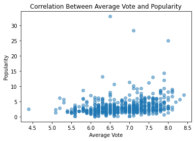

```python
# Defining our plotting function that will be used for all plots
def plotting (title, x, y, x_label, y_label):
    plt.scatter(x, y, alpha = 0.5)
    plt.xlabel(x_label)
    plt.ylabel(y_label)
    plt.title(title)
    plt.show()

plotting ('Correlation Between Average Vote and Popularity',df_loved_movies['vote_average'], df_loved_movies['popularity'],"Average Vote","Popularity")
```

#### Criteria 1: Production Companies

```python
df_loved_movies['production_companies'] = df_loved_movies['production_companies'].astype(str)
df_loved_movies_companies = df_loved_movies['production_companies'].str.cat(sep='|')
companies = pd.Series(df_loved_movies_companies.split('|'))
count_loved_movies_campanies = companies.value_counts(ascending = False).to_frame()
count_loved_movies_campanies.head(10)
```

|  | 0 |
| --- | --- |
| Warner Bros. | 78 |
| Universal Pictures | 64 |
| Twentieth Century Fox Film Corporation | 52 |
| Paramount Pictures | 51 |
| Columbia Pictures | 46 |
| Walt Disney Pictures | 41 |
| Village Roadshow Pictures | 23 |
| Amblin Entertainment | 23 |
| DreamWorks SKG | 22 |
| Legendary Pictures | 22 |

#### Criteria 2: Cast

```python
df_loved_movies['cast'] = df_loved_movies['cast'].astype(str)
df_loved_movies_companies = df_loved_movies['cast'].str.cat(sep='|')
companies = pd.Series(df_loved_movies_companies.split('|'))
count_loved_movies_campanies = companies.value_counts(ascending = False).to_frame()
count_loved_movies_campanies.head(50)
```

|  | 0 |
| --- | --- |
| Bruce Willis | 15 |
| Tom Hanks | 15 |
| Brad Pitt | 15 |
| Will Smith | 14 |
| Liam Neeson | 14 |
| Tom Cruise | 13 |
| Johnny Depp | 13 |
| Harrison Ford | 13 |
| Matt Damon | 12 |
| Ian McKellen | 11 |
| Hugh Jackman | 11 |
| Leonardo DiCaprio | 11 |
| Bradley Cooper | 11 |
| Samuel L. Jackson | 10 |
| Emma Watson | 10 |
| Jason Statham | 10 |
| Scarlett Johansson | 10 |
| Ralph Fiennes | 10 |
| Ewan McGregor | 10 |
| Helena Bonham Carter | 10 |
| Woody Harrelson | 9 |
| Arnold Schwarzenegger | 9 |
| Simon Pegg | 9 |
| Robert Downey Jr. | 9 |
| Jake Gyllenhaal | 9 |
| Cameron Diaz | 9 |
| Emma Stone | 9 |
| Christian Bale | 9 |
| Vin Diesel | 9 |
| James Franco | 8 |
| Jennifer Lawrence | 8 |
| Angelina Jolie | 8 |
| Morgan Freeman | 8 |
| Steve Buscemi | 8 |
| Daniel Craig | 8 |
| Mark Wahlberg | 8 |
| Jonah Hill | 8 |
| Robert De Niro | 8 |
| Michael Caine | 8 |
| Daniel Radcliffe | 8 |
| Rupert Grint | 8 |
| Gary Oldman | 8 |
| Rachel McAdams | 7 |
| Robin Williams | 7 |
| Natalie Portman | 7 |
| Mark Ruffalo | 7 |
| Anne Hathaway | 7 |
| Bill Nighy | 7 |
| Chris Hemsworth | 7 |
| Famke Janssen | 7 |

#### Insight

Sur la base de cette analyse, nous pouvons conclure qu'il n'y a pas de grande différence dans le score en fonction des acteurs. Par conséquent, le casting n'est pas un facteur de popularité du film du point de vue du public.

#### Criteria 3: Genres

```python
df_loved_movies['genres'] = df_loved_movies['genres'].astype(str)
df_loved_movies_companies = df_loved_movies['genres'].str.cat(sep='|')
companies = pd.Series(df_loved_movies_companies.split('|'))
count_loved_movies_campanies = companies.value_counts(ascending = False).to_frame()
count_loved_movies_campanies.head(10)
```

|  | 0 |
| --- | --- |
| Action | 269 |
| Adventure | 214 |
| Drama | 189 |
| Thriller | 189 |
| Science Fiction | 154 |
| Comedy | 140 |
| Fantasy | 111 |
| Crime | 90 |
| Family | 86 |
| Romance | 58 |

#### Insight

Sur la base de cet aperçu, nous pouvons conclure que les films d'action et d'aventure sont les plus appréciés par le public.

### Research Question 3: Un film populaire signifie-t-il directement un film commercialement réussi?

```python
df.corr()
```

|  | popularity | budget | revenue | runtime | vote_count | vote_average | release_year | profits | profits_rate | release_month |
| --- | --- | --- | --- | --- | --- | --- | --- | --- | --- | --- |
| popularity | 1.000000 | 0.202659 | 0.383233 | 0.202721 | 0.596094 | 0.259640 | 0.087858 | 0.331803 | 0.073844 | 0.070959 |
| budget | 0.202659 | 1.000000 | 0.641572 | 0.248744 | 0.372427 | -0.291898 | 0.331698 | 0.309054 | -0.315611 | -0.025521 |
| revenue | 0.383233 | 0.641572 | 1.000000 | 0.258827 | 0.586697 | 0.028012 | 0.094108 | 0.844550 | 0.116672 | 0.046008 |
| runtime | 0.202721 | 0.248744 | 0.258827 | 1.000000 | 0.343805 | 0.278602 | -0.097625 | 0.237715 | -0.032334 | 0.237782 |
| vote_count | 0.596094 | 0.372427 | 0.586697 | 0.343805 | 1.000000 | 0.356646 | 0.074523 | 0.486813 | 0.050545 | 0.048115 |
| vote_average | 0.259640 | -0.291898 | 0.028012 | 0.278602 | 0.356646 | 1.000000 | -0.371924 | 0.178383 | 0.260544 | 0.256641 |
| release_year | 0.087858 | 0.331698 | 0.094108 | -0.097625 | 0.074523 | -0.371924 | 1.000000 | -0.264863 | -0.443204 | -0.035009 |
| profits | 0.331803 | 0.309054 | 0.844550 | 0.237715 | 0.486813 | 0.178383 | -0.264863 | 1.000000 | 0.479454 | 0.041611 |
| profits_rate | 0.073844 | -0.315611 | 0.116672 | -0.032334 | 0.050545 | 0.260544 | -0.443204 | 0.479454 | 1.000000 | 0.023907 |
| release_month | 0.070959 | -0.025521 | 0.046008 | 0.237782 | 0.048115 | 0.256641 | -0.035009 | 0.041611 | 0.023907 | 1.000000 |

[figure not shown]

```python
plotting ('Correlation Between Profits Rate and Popularity',df_loved_movies['profits'], df_loved_movies['popularity'],"Average Vote","Popularity")
```

[figure not shown]

```python
plotting ('Correlation Between Profits Rate and Popularity',df_loved_movies['profits_rate'], df_loved_movies['popularity'],"Profits","Popularity")
```

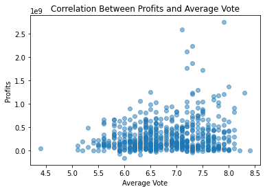

```python
plotting ('Correlation Between Profits and Average Vote',df_loved_movies['vote_average'], df_loved_movies['profits'],"Average Vote","Profits")
```

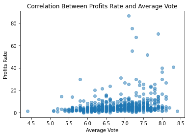

```python
plotting ('Correlation Between Profits Rate and Average Vote',df_loved_movies['vote_average'], df_loved_movies['profits_rate'],"Average Vote","Profits Rate")
```

### Evolution du Bénéfice par Année

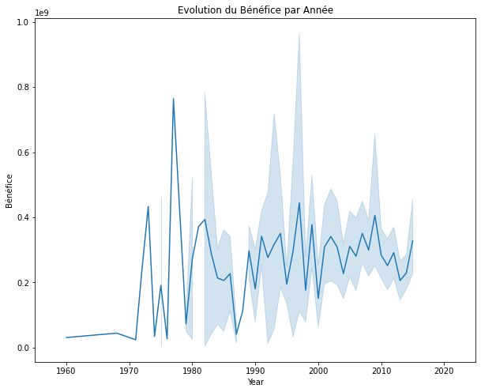

```python
df['prft'] = df['revenue'] - df['budget']
plt.figure(figsize=(10,8))
sns.lineplot(x = df['release_year'], y = df['prft'])
plt.title('Evolution du Bénéfice par Année')
plt.xlabel("Year")
plt.ylabel("Bénéfice")
plt.xlim(1955,2025)
plt.show()
```

#### Insight

L'évolution des bénéfices au fil des ans ne suit pas un schéma clair : elle est marquée par de nombreux hauts et bas, avec un pic significatif dans les années 70. Pour comprendre cette tendance, nous devons soit examiner en profondeur l'histoire de l'industrie cinématographique, soit étendre nos recherches et essayer de comprendre quels sont les facteurs qui ont contribué à ce pic à cette période.

## Conclusions

Tout au long de notre travail, nous avons conservé deux définitions principales du **succès**: Le succès commercial (bénéfices) et la popularité ( avis élevés des utilisateurs). Sur la base de ces deux définitions, nous avons travaillé à la détection des facteurs contribuant au succès global d'un film.

En conclusion, dans l'industrie cinématographique, les réalisateurs s'efforcent de faire le plus de profits possible et d'attirer le public. Pour cela, afin de réaliser un film populaire et à succès sur le plan commercial, ils doivent se concentrer sur deux facteurs principaux : **les genres et les sociétés de production**.

Les acteurs peuvent être un facteur important pour le film et peuvent générer plus de revenus, mais ils ne contribuent pas à générer plus de bénéfices (car pour générer plus de revenus, il faut plus de budget dans le cas des acteurs). Pour cela, le choix du cast dépend vraiment de la perspective du décideur.

### Limitations

Bien que ces données aient contribué à la compréhension de nombreux facteurs et relations, il leur manque encore certaines données qui pourraient rendre notre analyse et notre interprétation plus précises, comme l'importante quantité de données manquantes trouvées dans cette base de données. Plus important encore, il n'y avait pas de données claires pouvant être utilisées pour recueillir des informations sur l'évolution instable des bénéfices au fil des ans. Ce type de données aurait beaucoup aidé à conclure les facteurs et critères importants sur lesquels se concentrer dans l'industrie cinématographique et contribuerait énormément à sa croissance.

En outre, il serait plus efficace de construire un algorithme d'apprentissage automatique qui automatisera le processus de prédiction des films susceptibles d'avoir du succès commerciale et/ou popularité.